# Reproducible Research: Peer Assessment 1

## Loading and preprocessing the data

First lets read the data into a variable while specifying the class of each column:

```r
 data <- read.csv("activity.csv",colClasses=c("numeric","Date","numeric"))
```

## What is mean total number of steps taken per day?

In order to answer this question we use a data.table and ggplot2 for plotting a histogram.

```
## stat_bin: binwidth defaulted to range/30. Use 'binwidth = x' to adjust this.
```

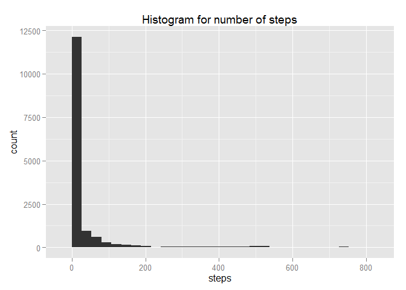

```r
#lets first draw the histogram to get a feel for the data
library(ggplot2)
#then make the histogram
p1 <- qplot(steps,data=data,main="Histogram for number of steps")
p1
```

So it seems that there are quite a few intervals with 0 steps taken. In order to complement this view, we look at a table showing mean and median for each day.

```r
#now on to the mean and median calculation. Load the data.table package
library(data.table)
#then make a data table
dt <- data.table(data)

#then calculate the mean and median per day
meanMedian <- dt[,list(mean=mean(steps,na.rm=TRUE),median=median(steps, na.rm = TRUE)),by=date]
meanMedian
```

```
##           date       mean median
##  1: 2012-10-01        NaN     NA
##  2: 2012-10-02  0.4375000      0
##  3: 2012-10-03 39.4166667      0
##  4: 2012-10-04 42.0694444      0
##  5: 2012-10-05 46.1597222      0
##  6: 2012-10-06 53.5416667      0
##  7: 2012-10-07 38.2465278      0
##  8: 2012-10-08        NaN     NA
##  9: 2012-10-09 44.4826389      0
## 10: 2012-10-10 34.3750000      0
## 11: 2012-10-11 35.7777778      0
## 12: 2012-10-12 60.3541667      0
## 13: 2012-10-13 43.1458333      0
## 14: 2012-10-14 52.4236111      0
```

[output cut: 48 more lines]

Indeed, the median is mostly 0 showing that there are many intervals with 0 steps taken per day.

## What is the average daily activity pattern?

Now we want to look closer at which intervals are active or not. We fist make a time series plot (line chart) of the 5-minute intervals (x-axis) and the average number of steps taken during each interval, averaged across all days (y-axis)

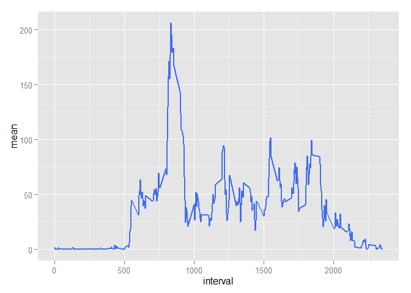

```r
#get the mean steps per interval
meanIntervalSteps <- dt[,list(mean=mean(steps,na.rm=TRUE),median=median(steps, na.rm = TRUE)),by=interval]

#plot them
ggplot(meanIntervalSteps,aes(interval,mean))+geom_line(colour = "royalblue2", size = 1)
```

Now we’ll try to calculate Which 5-minute interval, on average across all the days in the dataset, contains the maximum number of steps

```r
meanIntervalSteps$interval[which.max(meanIntervalSteps$mean)]
```

```
## [1] 835
```

## Imputing missing values

In order to deal with NAs we’ll do the following:

- Calculate and report the total number of missing values in the dataset (i.e. the total number of rows with NAs)

```r
#the number of NA values is:
length(which(is.na(data$steps)))
```

```
## [1] 2304
```

So the answer is: 2304 NA values

- Next we will replace NA values with the mean for that 5-minute interval over all days and create a new dataset that is equal to the original dataset but with the missing data filled in.

```r
modifiedData <- data

for(i in 1:nrow(modifiedData)){

    if(is.na(modifiedData$steps[i])){
       intval <- modifiedData[i,3]
       #get the average for this day
       avg <- meanIntervalSteps[interval == intval,]
       mean <- avg$mean

       #now fill the respective cell
       modifiedData[i,1] <- mean
    }
}
```

```r
library(gridExtra)
```

```
## stat_bin: binwidth defaulted to range/30. Use 'binwidth = x' to adjust this.
## stat_bin: binwidth defaulted to range/30. Use 'binwidth = x' to adjust this.
```

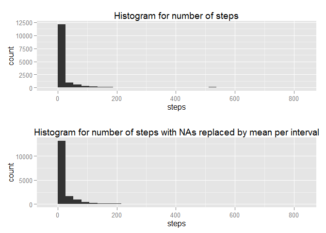

```r
#first show the new and old histogram side by side to check if we can see a difference
p2 <- qplot(steps,data=modifiedData,main="Histogram for number of steps with NAs replaced by mean per interval")
grid.arrange(p1, p2)
```

```r
#make a data table like before
dt2 <- data.table(modifiedData)

#then calculate the mean and median per day
meanMedian2 <- dt2[,list(mean=mean(steps,na.rm=TRUE),median=median(steps, na.rm = TRUE)),by=date]

#check if the values differ from those in the first part of the assignment
differenceTable <- data.frame(meanMedian$mean,meanMedian2$mean,meanMedian$median,meanMedian2$median)
names(differenceTable) <- c("original_mean","new_mean","original_median","new_median")
differenceTable$meanDifference <- differenceTable$original_mean - differenceTable$new_mean
differenceTable$medianDifference <- differenceTable$original_median - differenceTable$new_median
differenceTable
```

```
##    original_mean   new_mean original_median new_median meanDifference
## 1            NaN 37.3825996              NA   34.11321            NaN
## 2      0.4375000  0.4375000               0    0.00000              0
## 3     39.4166667 39.4166667               0    0.00000              0
## 4     42.0694444 42.0694444               0    0.00000              0
## 5     46.1597222 46.1597222               0    0.00000              0
## 6     53.5416667 53.5416667               0    0.00000              0
## 7     38.2465278 38.2465278               0    0.00000              0
## 8            NaN 37.3825996              NA   34.11321            NaN
## 9     44.4826389 44.4826389               0    0.00000              0
## 10    34.3750000 34.3750000               0    0.00000              0
## 11    35.7777778 35.7777778               0    0.00000              0
## 12    60.3541667 60.3541667               0    0.00000              0
## 13    43.1458333 43.1458333               0    0.00000              0
## 14    52.4236111 52.4236111               0    0.00000              0
```

[output cut: 109 more lines]

We can see that indeed there are a few differences in that mean and median exist for all days now.

- Now, lets answer: What is the impact of imputing missing data on the estimates of the total daily number of steps?

```r
#look at the total number of daily steps
#first in the original data
sumSteps <- dt[,list(stepCount=sum(steps,na.rm=TRUE)),by=date]
#now in the replaced data
sumSteps2 <- dt2[,list(stepCount=sum(steps,na.rm=TRUE)),by=date]

differenceTable <- data.frame(sumSteps$stepCount,sumSteps2$stepCount)
names(differenceTable) <- c("stepCountOriginal","stepCountNAReplaced")

differenceTable$Difference <- differenceTable$stepCountOriginal - differenceTable$stepCountNAReplaced
differenceTable
```

```
##    stepCountOriginal stepCountNAReplaced Difference
## 1                  0            10766.19  -10766.19
## 2                126              126.00       0.00
## 3              11352            11352.00       0.00
## 4              12116            12116.00       0.00
## 5              13294            13294.00       0.00
## 6              15420            15420.00       0.00
## 7              11015            11015.00       0.00
## 8                  0            10766.19  -10766.19
## 9              12811            12811.00       0.00
## 10              9900             9900.00       0.00
## 11             10304            10304.00       0.00
## 12             17382            17382.00       0.00
## 13             12426            12426.00       0.00
## 14             15098            15098.00       0.00
```

[output cut: 47 more lines]

We can see that replacing the values influenced those days in which the original step count was 0.

## Are there differences in activity patterns between weekdays and weekends?

- Lets create a new factor variable in the dataset with two levels - “weekday” and “weekend” indicating whether a given date is a weekday or weekend day.

```r
modifiedData$weekDays <- weekdays(modifiedData$date)
modifiedData$weekend <- factor(modifiedData$weekDays)
levels(modifiedData$weekend) <- c("weekday","weekday","weekday","weekday","weekday","weekend","weekend")
```

- Now lets make a panel plot containing a time series plot (i.e. type = “l”) of the 5-minute interval (x-axis) and the average number of steps taken, averaged across all weekday days or weekend days (y-axis).

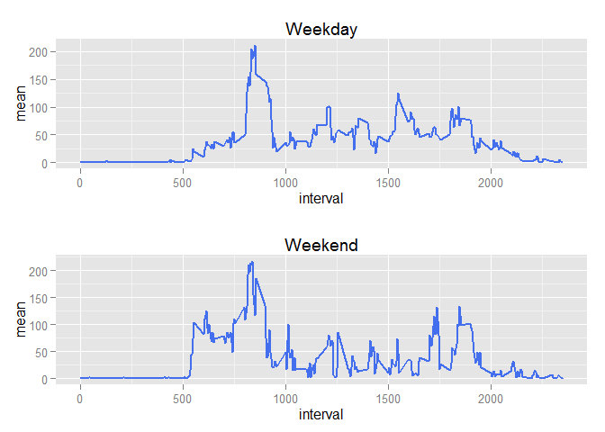

```r
dtweekday <- data.table(subset(modifiedData,weekend=="weekday"))
meanIntervalSteps_weekday <- dtweekday[,list(mean=mean(steps,na.rm=TRUE)),by=interval]

dtweekend <- data.table(subset(modifiedData,weekend=="weekend"))
meanIntervalSteps_weekend <- dtweekend[,list(mean=mean(steps,na.rm=TRUE)),by=interval]


p2 <- ggplot(meanIntervalSteps_weekend,aes(interval,mean))+geom_line(colour = "royalblue2", size = 1) + ggtitle("Weekend")
p1 <- ggplot(meanIntervalSteps_weekday,aes(interval,mean))+geom_line(colour = "royalblue2", size = 1) + ggtitle("Weekday")
grid.arrange(p1, p2)
```

So to answer the question, yes there are differences in patterns. The subject seems to be walking earlier on the weekend than on weekdays and also has more intervals with zero movement on the weekend. Lunchtime seems to involve quite a bit of walking in both cases.